# Neil Yetz Lab 2

# Load Packages

```r
library(tidyverse)
library(descriptr)
library(psych)
library(modelr)
library(olsrr)
library(GGally)
```

# Load data

```r
lab2 <- read_csv("Lab2.csv")
```

# Describe dataset

```r
describe(lab2)
```

```
   vars  n mean   sd median trimmed  mad  min   max range  skew kurtosis   se
x1    1 11  9.0 3.32   9.00    9.00 4.45 4.00 14.00 10.00  0.00    -1.53 1.00
y1    2 11  7.5 2.03   7.58    7.49 1.82 4.26 10.84  6.58 -0.05    -1.20 0.61
x2    3 11  9.0 3.32   9.00    9.00 4.45 4.00 14.00 10.00  0.00    -1.53 1.00
y2    4 11  7.5 2.03   8.14    7.79 1.47 3.10  9.26  6.16 -0.98    -0.51 0.61
x3    5 11  9.0 3.32   9.00    9.00 4.45 4.00 14.00 10.00  0.00    -1.53 1.00
y3    6 11  7.5 2.03   7.11    7.15 1.53 5.39 12.74  7.35  1.38     1.24 0.61
x4    7 11  9.0 3.32   8.00    8.00 0.00 8.00 19.00 11.00  2.47     4.52 1.00
y4    8 11  7.5 2.03   7.04    7.20 1.90 5.25 12.50  7.25  1.12     0.63 0.61
```

# Get Models

## M1

```r
m1 <- lm(data = lab2, y1 ~ x1)
ols_regress(m1)
```

```
                        Model Summary
--------------------------------------------------------------
R                       0.816       RMSE                1.237
R-Squared               0.667       Coef. Var          16.486
Adj. R-Squared          0.629       MSE                 1.529
Pred R-Squared          0.501       MAE                 0.837
--------------------------------------------------------------
 RMSE: Root Mean Square Error
 MSE: Mean Square Error
 MAE: Mean Absolute Error

                               ANOVA
-------------------------------------------------------------------
               Sum of
              Squares        DF    Mean Square      F         Sig.
-------------------------------------------------------------------
Regression     27.510         1         27.510     17.99    0.0022
Residual       13.763         9          1.529
Total          41.273        10
-------------------------------------------------------------------

                                Parameter Estimates
------------------------------------------------------------------------------------
      model     Beta    Std. Error    Std. Beta      t       Sig     lower    upper
------------------------------------------------------------------------------------
(Intercept)    3.000         1.125                 2.667    0.026    0.456    5.544
         x1    0.500         0.118        0.816    4.241    0.002    0.233    0.767
------------------------------------------------------------------------------------
```

### M1 description

Overall, x1 explaines 66.7% of the variance in y1, overall this is a significant amount of variance explained F(1,9) = 17.99, p = 0.0022. When x1 is 0 we estimate y1 to be at 3.00. Additionally, for every 1 unit change in x1, we expecte to see a 0.5 change in y1.

## M2

```r
m2 <- lm(data = lab2, y2 ~ x2)
ols_regress(m2)
```

```
                        Model Summary
--------------------------------------------------------------
R                       0.816       RMSE                1.237
R-Squared               0.666       Coef. Var          16.494
Adj. R-Squared          0.629       MSE                 1.531
Pred R-Squared          0.413       MAE                 0.968
--------------------------------------------------------------
 RMSE: Root Mean Square Error
 MSE: Mean Square Error
 MAE: Mean Absolute Error

                               ANOVA
-------------------------------------------------------------------
               Sum of
              Squares        DF    Mean Square      F         Sig.
-------------------------------------------------------------------
Regression     27.500         1         27.500    17.966    0.0022
Residual       13.776         9          1.531
Total          41.276        10
-------------------------------------------------------------------

                                Parameter Estimates
------------------------------------------------------------------------------------
      model     Beta    Std. Error    Std. Beta      t       Sig     lower    upper
------------------------------------------------------------------------------------
(Intercept)    3.001         1.125                 2.667    0.026    0.455    5.547
         x2    0.500         0.118        0.816    4.239    0.002    0.233    0.767
------------------------------------------------------------------------------------
```

### M2 description

Overall, x2 explaines 66.6% of the variance in y2, overall this is a significant amount of variance explained F(1,9) = 17.97, p = 0.0022. When x1 is 0 we estimate y1 to be at 3.001. Additionally, for every 1 unit change in x2, we expect to see a 0.5 change in y2.Please note, there is a marked difference between our R^2 value and predicted predicted R^2 value, so there may be a problem of model fit.

## M3

```r
m3 <- lm(data = lab2, y3 ~ x3)
ols_regress(m3)
```

```
                        Model Summary
--------------------------------------------------------------
R                       0.816       RMSE                1.236
R-Squared               0.666       Coef. Var          16.484
Adj. R-Squared          0.629       MSE                 1.528
Pred R-Squared          0.427       MAE                 0.716
--------------------------------------------------------------
 RMSE: Root Mean Square Error
 MSE: Mean Square Error
 MAE: Mean Absolute Error

                               ANOVA
-------------------------------------------------------------------
               Sum of
              Squares        DF    Mean Square      F         Sig.
-------------------------------------------------------------------
Regression     27.470         1         27.470    17.972    0.0022
Residual       13.756         9          1.528
Total          41.226        10
-------------------------------------------------------------------

                                Parameter Estimates
------------------------------------------------------------------------------------
      model     Beta    Std. Error    Std. Beta      t       Sig     lower    upper
------------------------------------------------------------------------------------
(Intercept)    3.002         1.124                 2.670    0.026    0.459    5.546
         x3    0.500         0.118        0.816    4.239    0.002    0.233    0.766
------------------------------------------------------------------------------------
```

### M3 description

Overall, x3 explaines 66.6% of the variance in y3, overall this is a significant amount of variance explained F(1,9) = 17.97, p = 0.0022. When x1 is 0 we estimate y1 to be at 3.002. Additionally, for every 1 unit change in x3, we expect to see a 0.5 change in y3.Please note, there is a marked difference between our R^2 value and predicted predicted R^2 value, so there may be a problem of model fit.

## M4

```r
m4 <- lm(data = lab2, y4 ~ x4)
ols_regress(m4)
```

```
                        Model Summary
--------------------------------------------------------------
R                       0.817       RMSE                1.236
R-Squared               0.667       Coef. Var          16.474
Adj. R-Squared          0.630       MSE                 1.527
Pred R-Squared           -Inf       MAE                 0.903
--------------------------------------------------------------
 RMSE: Root Mean Square Error
 MSE: Mean Square Error
 MAE: Mean Absolute Error

                               ANOVA
-------------------------------------------------------------------
               Sum of
              Squares        DF    Mean Square      F         Sig.
-------------------------------------------------------------------
Regression     27.490         1         27.490    18.003    0.0022
Residual       13.742         9          1.527
Total          41.232        10
-------------------------------------------------------------------

                                Parameter Estimates
------------------------------------------------------------------------------------
      model     Beta    Std. Error    Std. Beta      t       Sig     lower    upper
------------------------------------------------------------------------------------
(Intercept)    3.002         1.124                 2.671    0.026    0.459    5.544
         x4    0.500         0.118        0.817    4.243    0.002    0.233    0.766
------------------------------------------------------------------------------------
```

# Scatterplot

## m1

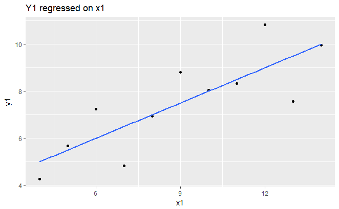

```r
ggplot(data=lab2, aes(x = x1, y = y1)) +
geom_point() +
geom_smooth(method = "lm", se = FALSE) +
labs(title = "Y1 regressed on x1",
x = "x1", y = "y1")
```

## m2

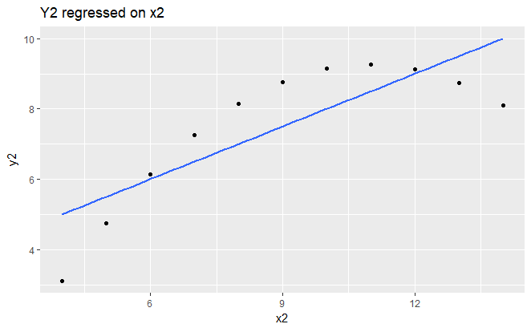

```r
ggplot(data=lab2, aes(x = x2, y = y2)) +
geom_point() +
geom_smooth(method = "lm", se = FALSE) +
labs(title = "Y2 regressed on x2",
x = "x2", y = "y2")
```

## m3

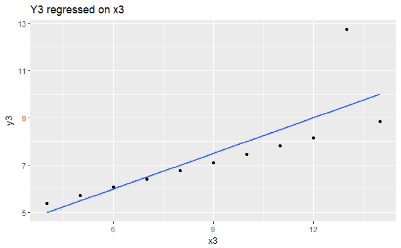

```r
ggplot(data=lab2, aes(x = x3, y = y3)) +
geom_point() +
geom_smooth(method = "lm", se = FALSE) +
labs(title = "Y3 regressed on x3",
x = "x3", y = "y3")
```

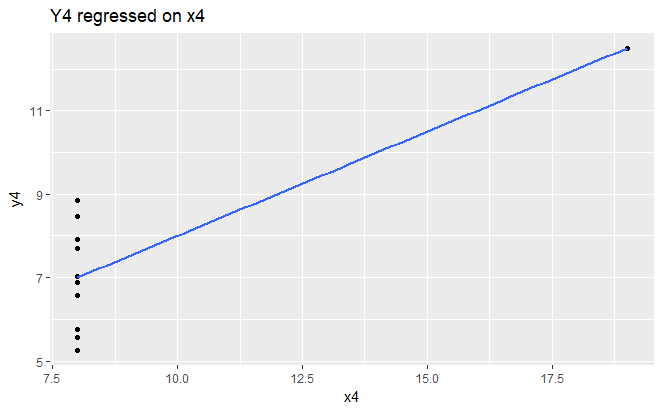

```r
ggplot(data=lab2, aes(x = x4, y = y4)) +
geom_point() +
geom_smooth(method = "lm", se = FALSE) +
labs(title = "Y4 regressed on x4",
x = "x4", y = "y4")
```

### Paragraph about plots

Looking at these 4 plots It is easy to see that the you can see that these data are spread very differently. For plot one, it looks like it is a very linear line and the regression line does a pretty good job at explaining what is going on. However, plot two looks a little bit different, it as creating a negative quadratic effect. Or rather, curvilinear, and the regression line doesn’t do a good job at fitting that line. Next, for plot 3, the almost does a good job of fitting the line, but it is being pulled by 1 outlier. thus, making the line deviate from the actual fitted line across nearly all values. I bet if we removed the outlier from model 3, we would get a much more fitted line. Lastly, for the last line, all of the data points, except for one, fall directly on 8 on the x axis. In reality, it should be an infinite line that fits across this (straight up and down) However, there is one outlier, causing a linear line to fit with a slope. In reality, my interpretation changed across all of the models except for model 1 when I viewed the data on a plot. None of these models are doing a very good job at predicting their associated y values.